# BSAN2204

Tutorial 3 - R Markdown

## What is R Markdown?

R Markdown is an authoring framework that allows you to combine narrative text, code, and output (plots or tables linked to data) in a single, reproducible document. R Markdown comes built into R Studio.

The syntax of R Markdown is built on `markdown` (which you might already know). R Markdown integrates seamlessly with `R`, but also works with `python` and many other languages.

R Markdown documents can be rendered to variety of file formats (HTML, PDF, RevealJS presentations, Shiny apps/dashboards, and websites).

**The Predictive Analytics Report (A2) and final Practical Demonstration (A3) in BSAN2204 require to write a report using R Markdown**, and submit them rendered `.html` files.

## Today’s goal: knit a `.html` file

We will get start on the **Predictive Analytics Report (A2)** today by building a blank template `.Rmd` file and check that you can render it to a `.html` file. Complete this check list:

1. Setup the YAML with your name/student number, assignment title and ensure `output:` is set to `html`
2. Setup the first `R` chunk to specify document defaults:  
   `echo = TRUE`, `eval = TRUE`, `warning = FALSE`, `message = FALSE`, `out.width = "100%"`
3. Setup the next `R` code chunk that loads the `MSD.RData` file from root.
4. Setup all the necessary main section headings as outlined in the assignment information within the course profile
5. Write some example text and include some basic sample `R` outputs

## Open the template `.Rmd` file

File > New File > R Markdown

Set the title: `Predictive Analytics Report (A2)`

Fill in your name: `Firstname SURNAME (s1234567)`

Confirm the default output format is set to: `HTML`

[figure not shown]

[figure not shown]

## Save the `*.Rmd` file

Before we start editing the document, save it to your working directory.

This should be the same place you are storing the `MSD.RData` file, ideally somewhere sensible like `.../username/documents/BSAN2204/`

(e.g., `SURNAME_firstname_s1234567_BSAN2204_A2.Rmd`).

## Parts of an R Markdown file (`.Rmd`)

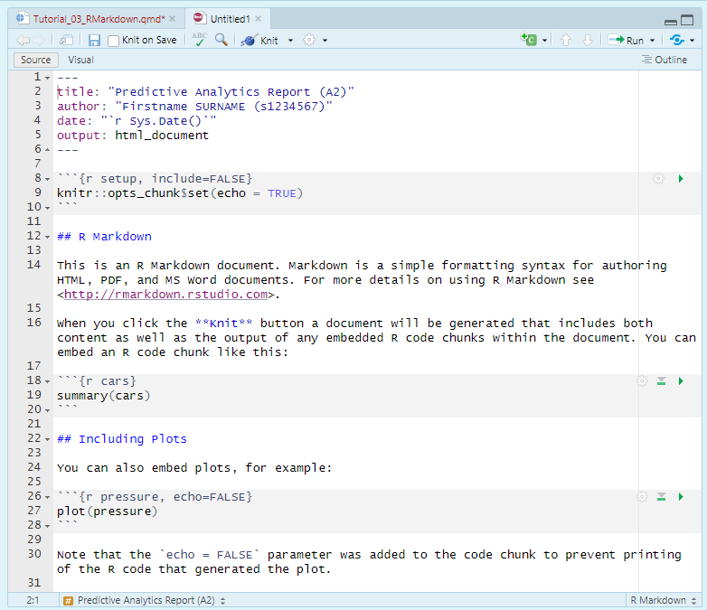

YAML (document header)

Document defaults

Plaintext (formatted using `markdown` syntax)

Code chunks inserted inside:

````markdown
```{r}
<code goes here>
```
````

## Check the YAML (document header)

The YAML sets the basic layout of the document. In simplest form, with: `output: html_document` and no other customisation provided we get a very standardised format.

[output not shown]

The data you entered when opening the new `.Rmd` file will appear here. If you need to change anything, you can edit the text here (i.e., there is no need to re-open a new template!). Additional document customisation settings can be placed here (you are encouraged to research these on your own).

## Set the document defaults

It is recommended to set `echo = TRUE`, `eval = TRUE`, `warning = FALSE`, `message = FALSE`, and `out.width = "100%"` in a special code chunk to set document default behaviours.

The option `include = FALSE` means the code will be run, but nothing from it will be shown in the document. `out.width = "100%"` ensures all plots fill the available horizontal space within the report.

````markdown
```{r setup, include=FALSE}
library(knitr)
opts_chunk$set(echo = TRUE)
opts_chunk$set(eval = TRUE)
opts_chunk$set(warning = FALSE)
opts_chunk$set(message = FALSE)
opts_chunk$set(out.width = "100%")
```
````

## Main section headings

You can safely delete (overwrite) the example contents in the template `.Rmd` file. Copy in the section headings outlined in the assessment information available in the course profile.

Recall that section headings are specified using `markdown` syntax, which defines headings using the `#` symbol. The fewer the `#`’s, the larger the heading. We recommend using Level 2 headings (i.e., `##`) for the main section headings. You can add Level 3 (`###`) subsections headings later.

```markdown
## 1. Introduction

## 2. Exploratory Analysis

## 3. Predictive Analytics

## 4. Recommendations
```

## First `R` chunk

Use keyboard short cut `ctrl+alt+i` insert a fenced off `R` code chunk.

````markdown
## 1. Introduction

```{r data processing}
load('MSD.RData')
```

## 2. Exploratory Analysis

## 3. Predictive Analytics

## 4. Recommendations
````

The data processing `R` code chunk in which the `load()` command to read in the `MSD.RData` needs to come *before* any code which references objects within the `MSD` data frame.

## Naming `R` code chunks

You *should* name each `R` chunk (for your own sake) as it helps you navigate your `.Rmd` file. Naming your `R` chunks does not affect your how your document renders.

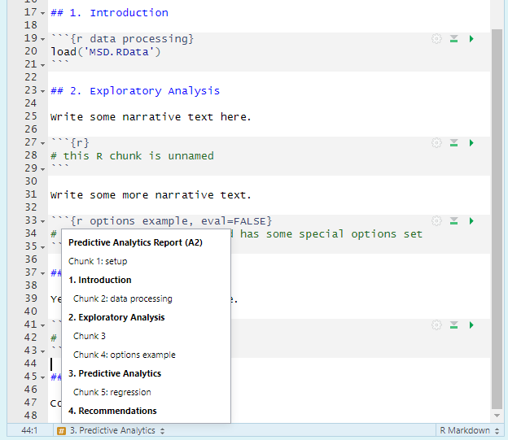

Name your `R` chunks as follows:

````markdown
```{r data processing}

```
````

If an `R` chunk has special options, place them after a comma

````markdown
```{r options example, eval = FALSE}


```
````

See the navigation options this enables at the bottom of your `.Rmd` file!

## Knit the document

Check that you can *knit* the `.Rmd` file and view output `.html` file.

When we click the knit button (🧶), or use keyboard shortcut `ctrl+shift+k`, the file will run from start to end in its own **local environment**. The the `MSD.RData` file and the `.Rmd` file must be in the **same location**. The `.html` file will also be saved to this location.

[figure not shown]

## Error?

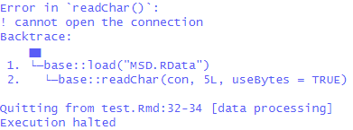

This is perhaps the most common error novice `R` users make when attempting to knit their first R Markdown document! It tends to arise due to a misunderstanding about the difference between the **global environment** and **local environment**.

## Global vs Local Environments

The **global environment** refers to the `R` objects that currently exist in your active `R` session. You can view these in the top-right panel of RStudio, under the Environment tab.

The **local environment** refers to the `R` objects created within your `.Rmd` file during knitting. When an `.Rmd` is knitted, it is rendered in a clean environment that does not use the objects in your global environment. This is why it makes no difference whether `MSD` is loaded in your global environment as the knitting process will only recognise the objects that are created or loaded inside the `.Rmd` itself.

This distinction between the global and local environments also affects how R Markdown handles packages. Any packages you need must be loaded within the `.Rmd` file itself using `library()` or by calling functions using `::`

## Check the output `.html` file

The rendered `.html` should appear in your Viewer tab within RStudio (or maybe it will open in your web browser).

The `.html` file will be saved in the same location as your `.Rmd` file.

When you re-knit the `.Rmd` it will override any previously knitted files.

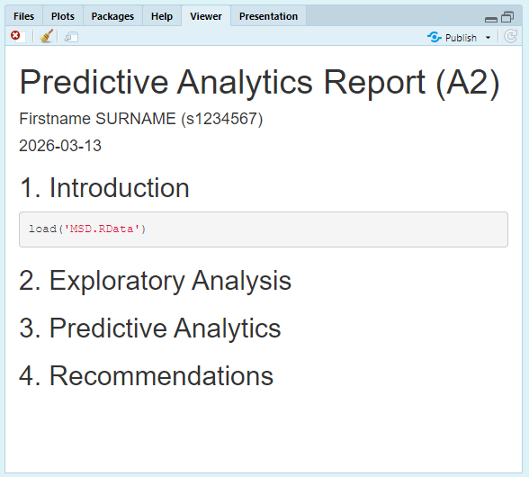

## Check in

Have you been able to render your `.Rmd` to `.html` successfully? Troubleshooting any issues you might be having with this is essential to do **now** rather than later. There are various other reasons (beyond your `.rdata` and `.Rmd` not being in the same directory) that can stop the knitting process.

Common issues include:

1. Not including `library()` commands for functions from non-base `R` packages.
2. Typos in code chunks. Even small spelling mistakes in object names, chunk options, or functions will cause knitting to stop.
3. Referencing objects that only exist in the global environment. Knitting uses a clean environment, so any objects must be created or loaded inside the .Rmd.
4. Not inserting `R` code within an fenced code block (or not closing the fence). This can be avoided by always using the keyboard short cut `ctrl+alt+i` when inserting a new code chunk.

## Start writing!

Start on your *Introduction* section now! Do some research about the Million Song Dataset and summarise it here. You do not need to know how do any coding to complete this part.

For now (here in the tutorial), just copy this place holder [lorem ipsum](https://en.wikipedia.org/wiki/Lorem_ipsum) text.

```markdown
## 1. Introduction

Lorem ipsum dolor sit amet, consectetur adipiscing elit. Morbi vitae diam non sem gravida
imperdiet quis in sapien. Curabitur urna dui, pulvinar nec sapien eu, porta sodales quam. Nulla
vitae facilisis risus. In consectetur fermentum velit sit amet volutpat. Morbi lobortis sit amet
justo id laoreet. Aenean tortor mauris, fermentum sed fringilla at, venenatis nec ante. Ut vitae
lacinia tortor, non fermentum mi. Phasellus euismod vel erat ac laoreet. Morbi ultricies ultricies
congue. Ut enim tellus, pellentesque ac lobortis dapibus, vulputate nec felis. Aliquam erat
volutpat. Integer pretium nulla a massa vulputate vulputate eget non mauris. Cras eu fringilla mi.
Nam sodales maximus felis et bibendum.
```

## Insert subsections

Insert subsection headings as Level 3 (`###`) headings.

````markdown
## 1. Introduction

### Data Processing

```{r data processing}
load('MSD.RData')
```

## 2. Exploratory Analysis

### Descriptive Statistics

### Visualisations

## 3. Predictive Analytics

### Initial Models

### Dealing with Missing Data

### Model Validation

### Predicitions

## 4. Recommendations
````

## Include some inline `R` code

The *Data Processing* subsection of the introduction section should include *some* of the code we developed in the last tutorial for checking the data structure, reported using inline code (i.e., weaving the values directly inside the text, rather than as `R` code chunks).

````markdown
### Data Processing

Write some text that describes what the MSD.Rdata file is, including some of your own background research
about where it comes from, etc. Echo the line of code which loads the data.

```{r data processing}
load('MSD.RData')
```

Write some more basic text that describes data structure. For example, you could report that there are
`r nrow(MSD)` rows in the data. Write some more text, and include some more inline code.
````

## Include some `R` outputs

The *Exploratory Analysis* section is where the large majority of `R` code which generates outputs will appear (tables formatted using functions like `kable()` and the output from data visualisation functions). For now, just insert place holder text, a basic table, and a basic plot (just to check that these work).

````markdown
## 3. Exploratory Analysis

Section introduction text.

### Descriptive Statistics

Some text. Here's a table:

```{r}
table(MSD$mode, MSD$time_signature) |> kable()
```

### Visualisations

More text. Here's a plot:

```{r}
plot(MSD$mode)
```
````

## Check the output `.html` again

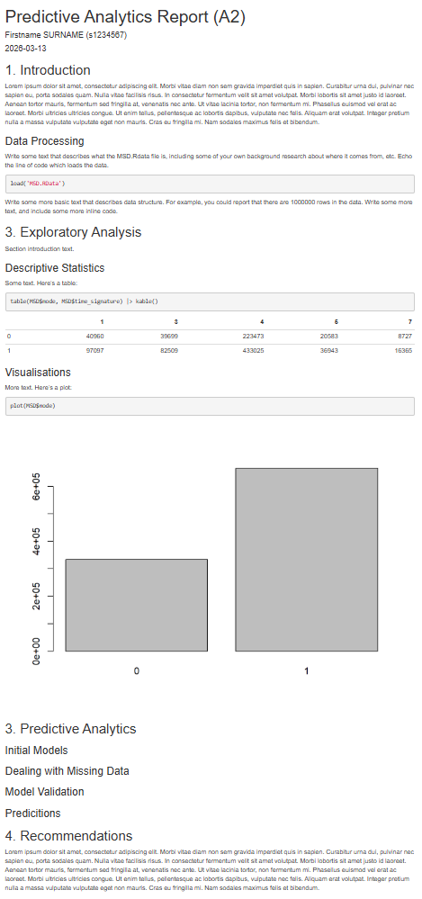

This completes the basic template you need to get started on the *Predictive Analytics Report (A2)*. As we progress through the tutorials, you can fill in each section with the code we develop in class.

The code we develop in class will serve as an example of what to include in each section, which you should adapt/personalise to suit your own analysis and focus in the assignment.

## What comes next?

In the next session we will cover the **data processing** steps introduced in the lecture, focussing specifically on how to incorporate them into your R Markdown document.

We will also spend time revising content in preparation for the R Skills Quiz (A1) which will be held in the following tutorial.

Thank you!